# Arm length vs. Height

I. N 7184

September 26, 2020

## I. Introduction

##### Using words, give a title to summarise what your assignment #1 is about.

##### This title should also be the title of your RMarkdown file.

##### Describe how your sample data was collected.

In class, we were put into several breakout rooms, where we discussed the lengths of our forearms and heights. Unfortunately, I wanted to wait for the data file instead so, I did not write down these values and will be using the a20a1data.csv file. As per the instructions, I have set the sedd to be the last four digits of my student number (7184) and randomly sampled 10 data points.

##### Specify your explanatory variable and response variable and, give a brief

##### explanation of your choice

The response, or the dependent variable is the arm length, while the explanatory, or independent variable is the height. This is because arm length should be based on the height of a person; depending on how tall a person is, we can assume, or try to guess, their forearm length.

## II. Exploratory Data Analysis

##### Draw at most 3 plots to visually describe your data. Is your response

##### variable approximately Normal?

```
##        id            height         forearm
##  Min.   :  5.0   Min.   :157.0   Min.   :16.00
##  1st Qu.: 41.5   1st Qu.:162.5   1st Qu.:21.25
##  Median :113.0   Median :166.0   Median :23.25
##  Mean   :147.4   Mean   :167.1   Mean   :25.15
##  3rd Qu.:261.0   3rd Qu.:173.8   3rd Qu.:27.75
##  Max.   :318.0   Max.   :177.0   Max.   :40.00
```

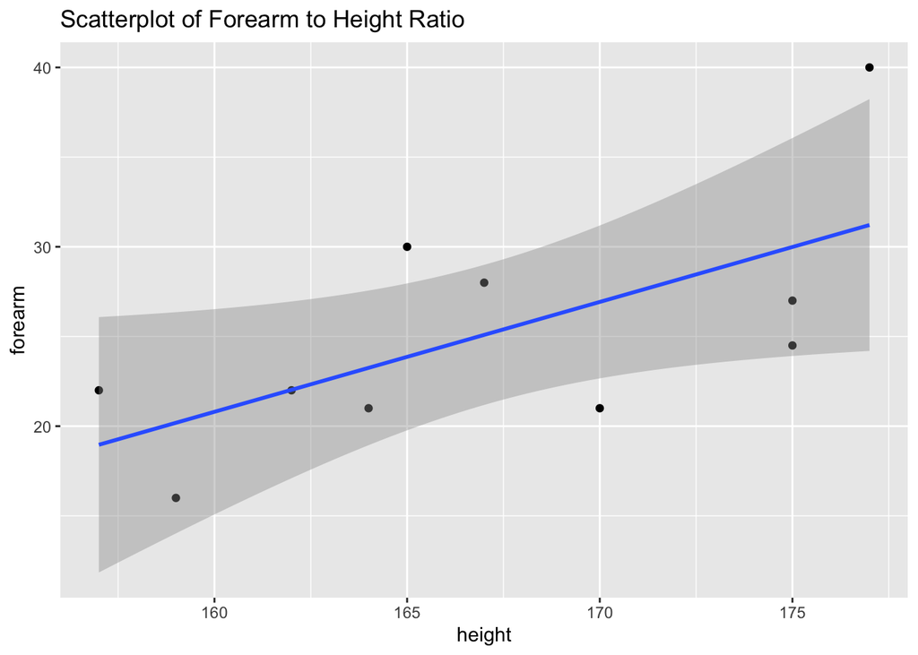

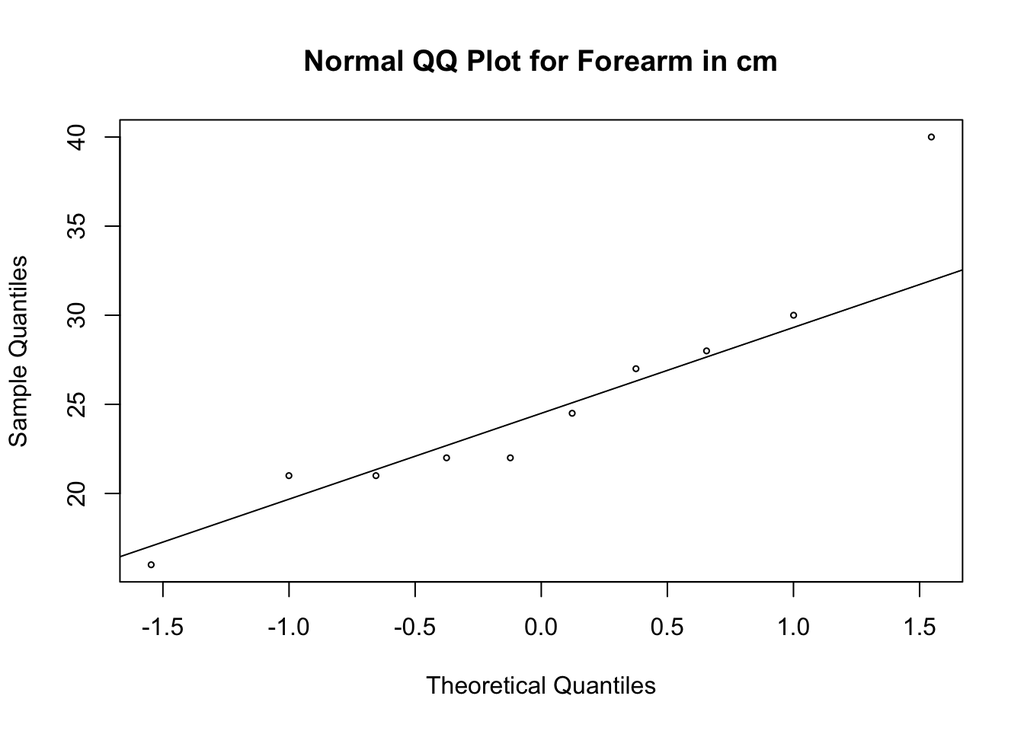

Yes, the response variable, ignoring one out-lier, seems to be fairly normal and gathered around the center of the qq normal plot, which dictates that the response variable is likely Normally distributed.

## III. Methods and Model

##### Fit and describe a linear regression model between forearm length and

##### height.

```
##
## Call:
## lm(formula = forearm ~ height)
##
## Residuals:
##    Min     1Q Median     3Q    Max
## -5.926 -3.889 -1.139  3.005  8.786
##
## Coefficients:
##             Estimate Std. Error t value Pr(>|t|)
## (Intercept) -77.2078    42.7395  -1.806   0.1085
## height        0.6126     0.2556   2.397   0.0434 *
## ---
## Signif. codes:  0 '***' 0.001 '**' 0.01 '*' 0.05 '.' 0.1 ' ' 1
##
## Residual standard error: 5.354 on 8 degrees of freedom
## Multiple R-squared:  0.418,  Adjusted R-squared:  0.3452
## F-statistic: 5.745 on 1 and 8 DF,  p-value: 0.04339
```

The error seems to be quite large, since some of the points (notably (177, 40)) are quite far away from the SLR model.

##### Are the regression parameters zero?

No, the Y intercept variable is not zero, as seen in the summary window. The intercept parameter is -77.2078. The slope parameter is 0.6126.

##### Interpret the estimates of the regression parameters

Because the Y intercept is below zero, nor is it close to zero, it is reasonable to say that perhaps the relation between forearm and height is not linear. Since the value of the y-intercept is very negative (estimated to be around -77.2), one could assume that if the relation were indeed linear, then either the data provided was very incorrect, or there were out-lier people. Also, the p-value is rounded to 0.0434 as we can see on the summary page.

## IV. Discussions and Limitations

##### Identify another pair of variables to explore a simple linear regression

##### model. Specify the response variable.

Another possible pair of variables to explore a simple linear regression model would be the relationship between height and status. Under the lens of one’s status, whether it be rich or poor or in a first/third world country, we can look at how much one’s height is affected. This would have potential since the more affluent have greater access to better nutrients. The response variable in this case is height while the explanatory variable would be their status.